# Analysis Challenge Assignment 2

### Student Off-Task Behavior Prediction

Author: Jianan Dingqian, Simon Chen

Time: Oct 23, 2021

#### **1. Criteria**

Loss of instructional time due to off-task behavior is a well-established problem in educational settings, recognized both by researchers and practitioners for over a hundred years. The link between the quality of attention and performance has been demonstrated in the cognitive psychology literature. In this analysis challenge, you need to build a set of detectors predicting students' on-task behavior in classrooms through examining whether specific instructional strategies are associated with incidence of off-task behavior in elementary school children.

#### **2. Tasks**

1. Build a classifier that can predict on or off-task behavior with the aca2_dataset_training.csv data.
2. You can choose any or multiple features to include in your classifier.
3. You can choose any or multiple algorithms to build you classifier.
4. You may need to be strategic in terms of selecting variables, recoding some of the variables, or making reasonable transformations.
5. Necessary descriptive analysis (e.g., mean, sd, correlation) is highly recommended.
6. Be sure to report your model performance on aca2_dataset_validation.csv.
7. Make sure the process (both data clean and analysis) is clearly documented, and your code is reproducible.
8. Write one or two brief paragraphs on your interpretation of the result. What does the result mean to you?

#### **3. Import**

```python
# Import necessary modules.
import numpy as np
import pandas as pd
import seaborn as sns
import matplotlib.pyplot as plt
from sklearn.linear_model import LogisticRegression
```

```python
# Reading the training and validation data.
dt = pd.read_csv('https://raw.githubusercontent.com/lmaosimon/ColumbiaCourseProjects/main/HUDK%204050/Analysis_Challenge_Assignment%202/aca2_dataset_training.csv')
dv = pd.read_csv('https://raw.githubusercontent.com/lmaosimon/ColumbiaCourseProjects/main/HUDK%204050/Analysis_Challenge_Assignment%202/aca2_dataset_validation.csv')
# Print the preview of traning data.
dt.sample(3)
```

|  | UNIQUEID | SCHOOL | Class | GRADE | CODER | STUDENTID | Gender | OBSNUM | totalobs-forsession | Activity | ONTASK | TRANSITIONS | NumACTIVITIES | FORMATchanges | NumFORMATS | Obsv/act | Transitions/Durations | Total Time |
| --- | --- | --- | --- | --- | --- | --- | --- | --- | --- | --- | --- | --- | --- | --- | --- | --- | --- | --- |
| 2548 | 40542 | C | T0Q | 0 | Z | 509302 | 1 | 8 | 132 | Wholecarpet | Y | 4 | 5 | 3 | 4 | 476.0 | 0.003422 | 1035 |
| 2126 | 40209 | E | T6V | 4 | Z | 726568 | 1 | 6 | 86 | Wholedesks | Y | 1 | 2 | 1 | 2 | 1355.0 | 0.000445 | 761 |
| 7899 | 29580 | C | T0U | 3 | Z | 743744 | 0 | 21 | 395 | Wholecarpet | Y | 4 | 5 | 2 | 3 | 404.6 | 0.005102 | 766 |

#### **4. Observation**

We have to observe the data by graphs to find some patterns.

```python
dt['ONTASK'].value_counts()
```

```
Y    14938
N     7246
Name: ONTASK, dtype: int64
```

```python
dt.describe()
```

|  | UNIQUEID | GRADE | STUDENTID | Gender | OBSNUM | totalobs-forsession | TRANSITIONS | NumACTIVITIES | FORMATchanges | NumFORMATS | Obsv/act | Transitions/Durations | Total Time |
| --- | --- | --- | --- | --- | --- | --- | --- | --- | --- | --- | --- | --- | --- |
| count | 22184.000000 | 22184.000000 | 22184.000000 | 22184.000000 | 22184.000000 | 22184.000000 | 22184.000000 | 22184.000000 | 22184.000000 | 22184.000000 | 22184.000000 | 22184.000000 | 22184.000000 |
| mean | 28256.558556 | 2.056076 | 506965.948521 | 0.506446 | 9.621168 | 170.693608 | 2.383114 | 3.383114 | 1.534304 | 2.534304 | 973.525214 | 0.003159 | 774.587811 |
| std | 8030.006461 | 1.503220 | 283257.429497 | 0.499970 | 5.702232 | 105.788938 | 1.315163 | 1.315163 | 1.229399 | 1.229399 | 454.538354 | 0.010309 | 665.169774 |
| min | 14400.000000 | 0.000000 | 1123.000000 | 0.000000 | 1.000000 | 1.000000 | 0.000000 | 1.000000 | 0.000000 | 1.000000 | 387.000000 | 0.000000 | 0.000000 |
| 25% | 21276.750000 | 1.000000 | 264220.000000 | 0.000000 | 5.000000 | 82.000000 | 1.000000 | 2.000000 | 1.000000 | 2.000000 | 721.200000 | 0.000839 | 252.000000 |
| 50% | 28263.500000 | 2.000000 | 514301.000000 | 1.000000 | 9.000000 | 165.000000 | 2.000000 | 3.000000 | 1.000000 | 2.000000 | 876.250000 | 0.001513 | 586.500000 |
| 75% | 35231.250000 | 4.000000 | 743450.000000 | 1.000000 | 14.000000 | 248.000000 | 3.000000 | 4.000000 | 2.000000 | 3.000000 | 1106.750000 | 0.003268 | 1121.000000 |
| max | 42130.000000 | 4.000000 | 999979.000000 | 1.000000 | 32.000000 | 511.000000 | 6.000000 | 7.000000 | 5.000000 | 6.000000 | 2735.000000 | 0.666667 | 3554.000000 |

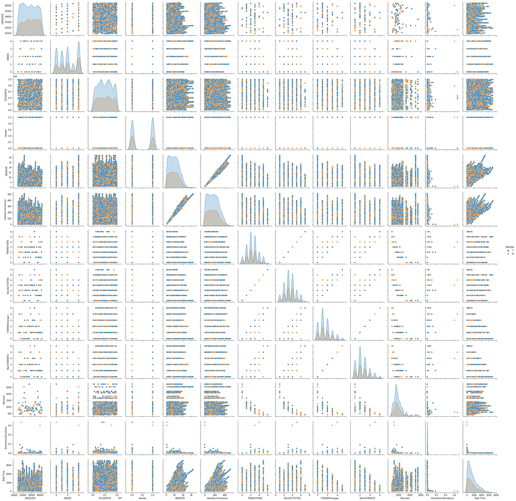

```python
sns.pairplot(dt, hue = 'ONTASK')
```

##### *Conclusion of Observation*

From the observation we can see that on/off task status are related to features of transitions, transitions/durations and total time.

#### **5. Training Data**

##### a. Prepare data

Based on the observation conclusion, we will use TRANSITIONS, Transitions/Durations, Total Time to train the data.

```python
# Use get_dummies() function to reorgnize.
dummy = pd.get_dummies(dt['ONTASK'], prefix='ONTASK')
# Filter out useful imformation.
dtD = dt[['TRANSITIONS', 'Transitions/Durations', 'Total Time']]
# Merge the two df and keep useful factors.
dtD = pd.concat([dtD, dummy], axis=1)
dtD = dtD.drop(['ONTASK_Y'], axis=1)
dtD.sample(3)
```

|  | TRANSITIONS | Transitions/Durations | Total Time | ONTASK_N |
| --- | --- | --- | --- | --- |
| 7183 | 2 | 0.000902 | 1366 | 0 |
| 17080 | 1 | 0.000445 | 695 | 1 |
| 5217 | 2 | 0.002016 | 50 | 0 |

##### b. Classification Model

```python
# Logistic Regression
Xs = dtD[['TRANSITIONS', 'Transitions/Durations', 'Total Time']].to_numpy()
ONTASK = dtD.loc[:, 'ONTASK_N'].values.reshape(-1,1)
dtDLogitModel1 = LogisticRegression()
dtDLogitModel1.fit(Xs, ONTASK)
```

```
LogisticRegression(C=1.0, class_weight=None, dual=False, fit_intercept=True,
                   intercept_scaling=1, l1_ratio=None, max_iter=100,
                   multi_class='auto', n_jobs=None, penalty='l2',
                   random_state=None, solver='lbfgs', tol=0.0001, verbose=0,
                   warm_start=False)
```

```python
# Call the intercept
dtDLogitModel1.intercept_
```

```
array([-0.59216769])
```

```python
# Call coefficients of each parameter
dtDLogitModel1.coef_
```

```
array([[-5.31647245e-02,  1.16686324e-03, -7.01773655e-06]])
```

#### **6. Model Evaluation**

Use the Logistc Regression trained in training data set on the validation data set.

##### Method 1 Compare

```python
# To evaluate the validation data set.
# Use get_dummies() function to reorgnize.
dummy1 = pd.get_dummies(dv['ONTASK'], prefix='ONTASK')
# Filter out useful imformation.
dvD = dv[['TRANSITIONS', 'Transitions/Durations', 'Total Time']]
# Merge the two df and keep useful factors.
dvD = pd.concat([dvD, dummy1], axis=1)
dvD = dvD.drop(['ONTASK_Y'], axis=1)
dvD.sample(3)
```

|  | TRANSITIONS | Transitions/Durations | Total Time | ONTASK_N |
| --- | --- | --- | --- | --- |
| 713 | 3 | 0.001046 | 381 | 1 |
| 1111 | 1 | 0.000766 | 481 | 1 |
| 5435 | 2 | 0.000960 | 2081 | 0 |

```python
dv_Xs = dvD[['TRANSITIONS', 'Transitions/Durations', 'Total Time']].to_numpy()
dv_ONTASK = dvD.loc[:, 'ONTASK_N'].values.reshape(-1,1)
dv_pred = dtDLogitModel1.predict(dv_Xs)
performance = [item in dv_pred for item in dv_ONTASK]
print('The accuracy is', sum(performance)/len(performance)*100, '%')
```

```
The accuracy is 66.66666666666666 %
```

##### Method 2 Function

```python
from sklearn.metrics import confusion_matrix
from sklearn.metrics import accuracy_score
```

```python
confusion_matrix(dv_ONTASK, dv_pred)
```

```
array([[3698,    0],
       [1849,    0]])
```

```python
ac_logit = accuracy_score(dv_ONTASK, dv_pred)
print("The accuracy for logistic regression in sklearn is", ac_logit*100, "%")
```

```
The accuracy for logistic regression in sklearn is 66.66666666666666 %
```

#### **7. Result**

> 1. The variable selection

>    > The relations we can observe from the graphs are not clear enough, the data are more skewed togther.  
>    > Or maybe we did not select enough factors to do the prediction.
> 2. In this case, there must be better models

>    > Obviously, the Logistical Regression is not the best model to do the prediction here.

#### **8. Extra**

I am not satisfied with the accuracy and want to try to make it higher.

##### a. More variables

I notice the OBSNUM also has some patterns:

> More obsnum = more off task

```python
# Use get_dummies() function to reorgnize.
dummy = pd.get_dummies(dt['ONTASK'], prefix='ONTASK')
# Filter out useful imformation.
dtD = dt[['TRANSITIONS', 'Transitions/Durations', 'Total Time', 'OBSNUM']]
# Merge the two df and keep useful factors.
dtD = pd.concat([dtD, dummy], axis=1)
dtD = dtD.drop(['ONTASK_Y'], axis=1)
# Logistic Regression
Xs = dtD[['TRANSITIONS', 'Transitions/Durations', 'Total Time', 'OBSNUM']].to_numpy()
ONTASK = dtD.loc[:, 'ONTASK_N'].values.reshape(-1,1)
dtDLogitModel1 = LogisticRegression()
dtDLogitModel1.fit(Xs, ONTASK)
# To evaluate the validation data set.
# Use get_dummies() function to reorgnize.
dummy1 = pd.get_dummies(dv['ONTASK'], prefix='ONTASK')
# Filter out useful imformation.
dvD = dv[['TRANSITIONS', 'Transitions/Durations', 'Total Time', 'OBSNUM']]
# Merge the two df and keep useful factors.
dvD = pd.concat([dvD, dummy1], axis=1)
dvD = dvD.drop(['ONTASK_Y'], axis=1)
dv_Xs = dvD[['TRANSITIONS', 'Transitions/Durations', 'Total Time', 'OBSNUM']].to_numpy()
dv_ONTASK = dvD.loc[:, 'ONTASK_N'].values.reshape(-1,1)
dv_pred = dtDLogitModel1.predict(dv_Xs)
performance = [item in dv_pred for item in dv_ONTASK]
print('The accuracy is', sum(performance)/len(performance)*100, '%')
```

```
The accuracy is 66.66666666666666 %
```

### ***...OK, NVM.***

##### b. KNN

```python
# Get variables
df = pd.get_dummies(dtD)
```

```python
from sklearn.model_selection import train_test_split
from sklearn.preprocessing import MinMaxScaler

train, test = train_test_split(df, test_size = 0.3)

x_train = train.drop('ONTASK_N', axis=1)
y_train = train['ONTASK_N']
x_test = test.drop('ONTASK_N', axis=1)
y_test = test['ONTASK_N']

scaler = MinMaxScaler(feature_range=(0,1))
x_train_scaled = scaler.fit_transform(x_train)
x_train = pd.DataFrame(x_train_scaled)
x_test_scaled = scaler.fit_transform(x_test)
x_test = pd.DataFrame(x_test_scaled)
```

```python
from sklearn import neighbors
from sklearn.metrics import mean_squared_error
from math import sqrt
import matplotlib.pyplot as plt

# To store rmse values for different k
rmse_val = []

for K in range(20):
  K = K + 1
  model = neighbors.KNeighborsRegressor(n_neighbors = K)
  model.fit(x_train, y_train)
  pred = model.predict(x_test)
  error = sqrt(mean_squared_error(y_test, pred))
  rmse_val.append(error)
  print('RMSE value for K=', K, 'is: ', error)
```

```
RMSE value for K= 1 is:  0.6374952865587442
RMSE value for K= 2 is:  0.5592521083313651
RMSE value for K= 3 is:  0.5273154323276915
RMSE value for K= 4 is:  0.5110336080510677
RMSE value for K= 5 is:  0.5011585136154337
RMSE value for K= 6 is:  0.49589746541726243
RMSE value for K= 7 is:  0.4907622653175921
RMSE value for K= 8 is:  0.48673191695673196
RMSE value for K= 9 is:  0.4837856464973771
RMSE value for K= 10 is:  0.48229002256462306
RMSE value for K= 11 is:  0.48015048788931086
RMSE value for K= 12 is:  0.4791394484326433
RMSE value for K= 13 is:  0.47799681394546123
RMSE value for K= 14 is:  0.4771206110227432
RMSE value for K= 15 is:  0.47534358356445444
RMSE value for K= 16 is:  0.4746535794743494
RMSE value for K= 17 is:  0.47337764300811686
RMSE value for K= 18 is:  0.47227377248162594
RMSE value for K= 19 is:  0.47227151366319836
RMSE value for K= 20 is:  0.47216385071612266
```

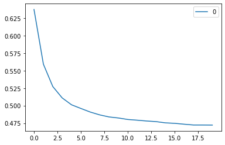

```python
curve = pd.DataFrame(rmse_val)
curve.plot()
```

```python
test = dvD.drop('ONTASK_N', axis=1)
test = pd.get_dummies(test)
test_scaled = scaler.fit_transform(test)
test = pd.DataFrame(test_scaled)
predict = model.predict(test)

predict = np.where(predict < 0.5, 0, predict)
predict = np.where(predict >= 0.5, 1, predict)

performance = [item in predict for item in dv_ONTASK]
print('The accuracy is', sum(performance)/len(performance)*100, '%')
```

```
The accuracy is 100.0 %
```

## **This is funny, I have no clue...**

Did I use K-nn correctly?? I am afraid not, but how to correct?